# Hyperparameter selection

Danny Morgant

2023-10-15

In this project we will explore some common ensemble learning methods as well as ways to select hyperparameters, from a simple toy problem.

We will work on a dataset containing concrete characteristics, and try to predict an output variable. This is a regression problem, and we will use four different algorithms: bagging, random forests, adaboost and gradient boosting. This project should help us get an introduction to the use of these algorithms, as well as exploring some strategies for selecting hyperparameters.

```python
from numpy import mean
import pandas as pd
import numpy as np
import matplotlib.pyplot as plt
import warnings
warnings.filterwarnings("ignore", category=DeprecationWarning)
from sklearn.ensemble import GradientBoostingClassifier
from sklearn.model_selection import KFold
from sklearn.metrics import make_scorer, mean_squared_error

plt.style.use('bmh')
```

## Data preparation

```python
# requires xlrd, see https://anaconda.org/anaconda/xlrd (installation via pip also available
df = pd.read_excel("Concrete_Data.xls")
y = df.iloc[:,8]
X = df.iloc[:,list(range(8))]
#X.head()
X.describe()
```

```
       Cement (component 1)(kg in a m^3 mixture)  ...    Age (day)
count                                1030.000000  ...  1030.000000
mean                                  281.165631  ...    45.662136
std                                   104.507142  ...    63.169912
min                                   102.000000  ...     1.000000
25%                                   192.375000  ...     7.000000
50%                                   272.900000  ...    28.000000
75%                                   350.000000  ...    56.000000
max                                   540.000000  ...   365.000000

[8 rows x 8 columns]
```

All features are continuous variables, and we don’t have any missing value. However the ranges are very different. We will therefore standardize all columns in the input data.

```python
X=(X-X.mean())/X.std()
```

### Preparation of datasets

We plan to utilize four algorithms, optimize their hyperparameters, and perform a comparative analysis. To enable a fair comparison, we require a set for comparison purposes. Ideally, each algorithm should also have distinct training and testing sets, but this would significantly reduce the data available for training the models. Consequently, we will employ cross-validation within the non-comparison set to train the models and fine-tune the hyperparameters.

As we intend to apply cross-validation to various models, it’s imperative that the cross-validation process remains consistent across all of them. Thus, we will establish the cross-validation splits in advance and use the same splits for each algorithm.

```python
from sklearn.model_selection import train_test_split, cross_val_score
from sklearn import model_selection

seed = 420
n_splits = 5

X0, X_compare, y0, y_compare = train_test_split(X, y, test_size=0.25, random_state=seed)
kfold = model_selection.KFold(n_splits=n_splits, shuffle=True, random_state=seed)
```

## Using different models

All the models we will use here are ensemble methods in which weak learners, which are decision trees, have their output combined in order to produce a so-called strong learner which will give us a prediction. All these models differ in the way the weak learners are constructed, and the way their contributions are combined.

### Bagging

Bagging, which stands for bootstrap aggregating, is a method in which we will choose the individual learners as decision trees. The training set is sampled with replacement (bootstrap), and is used to construct a decision tree. In a BaggingRegressor model, the output from the individual learners is average to produce the full model’s output.

There are two hyperparameters for a bagging model: the number of weak learners to introduce in the model and the size of the bootstrap samples to use to construct each of them.

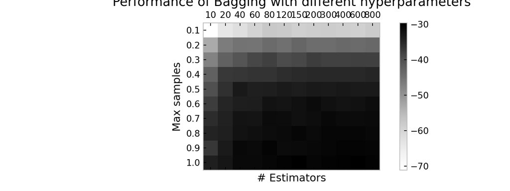

```python
from sklearn.ensemble import BaggingRegressor

grid = dict()
grid['n_estimators'] = [10, 20, 40, 60, 80, 120, 150, 200, 300, 400, 600, 800]
grid['max_samples'] = [0.1*i for i in range(1, 11)]

mses = np.zeros((len(grid["n_estimators"]), len(grid["max_samples"])))

for i, n_estimators in enumerate(grid["n_estimators"]):
    for j, max_samples in enumerate(grid["max_samples"]):
        #Making explicit that we are using Bagging algorithm
        model_bagging = BaggingRegressor(bootstrap=True, bootstrap_features=False,
                                         n_estimators=n_estimators,
                                         max_samples=max_samples)
        mses[i,j] = sum(cross_val_score(
            model_bagging, X0, y0, cv=kfold, n_jobs=-1, scoring='neg_mean_squared_error')) / n_splits

plt.rcParams["figure.figsize"] = (8, 3);
plt.rcParams['axes.grid'] = False
fig = plt.figure()
ax = fig.add_subplot(111)
cax = ax.matshow(mses.T, interpolation='nearest', cmap='Greys')
fig.colorbar(cax);

xaxis = np.arange(len(grid["n_estimators"]))
yaxis = np.arange(len(grid["max_samples"]))
ax.set_xticks(xaxis)
ax.set_yticks(yaxis)
ax.set_xticklabels(grid["n_estimators"]);
ax.set_yticklabels([f"{0.1*i:.1f}" for i in range(1, 11)]);
ax.set_ylabel("Max samples");
ax.set_xlabel("# Estimators");
ax.set_title("Performance of Bagging with different hyperparameters");

plt.show();
```

We used a grid search to try and find the best hyperparameters for bagging. Since there are only two of them, we can visualize them with a heatmap. We represented it it above, hoping to uncover a meaningful pattern. It appears that increasing the *max_samples*, meaning the size of the samples to bootstrap, helps the algorithm. However there seem to be a sweet spot for the number of estimators to build.

```python
hyp_argmax = np.unravel_index(np.argmax(mses), mses.shape)
bag_params = {"n_estimators": grid['n_estimators'][hyp_argmax[0]],
              "max_samples": grid['max_samples'][hyp_argmax[1]]}

# Store all prints in a string to fix rendering issues
printstring = f"Best hyperparameters: \n\tn_estimators = {bag_params['n_estimators']}\n\
\tmax_samples = {bag_params['max_samples']}"
print(printstring + f"\nBest mean squared error: {-mses[hyp_argmax]:.3f}")
```

```
Best hyperparameters:
    n_estimators = 150
    max_samples = 1.0
Best mean squared error: 29.637
```

### Random Forests

Random forests are also an ensemble method in which the individual learners are decision trees. In random forests, the totality of the training set but only a subset of the features are used to train each decision tree. The final estimation again is produced by averaging the predictions of each tree.

In random forests, there are a number of hyperparameters. We decided do find the best combination of four of them. The number of estimators to use in the model is the first one, and is common to all methods we will use in this document. The number of features to use is the first characteristic of random forests. For the construction of each tree we will also try to find optimal values for its maximum depth as well as the number of points to be present in a group after division for this group to be considered a leaf.

Hyperparameter optimization through grid search is acknowledged to be highly inefficient. A commonly used alternative search method is randomized search, which involves testing random hyperparameter combinations and selecting the best-performing one. We start with the standard grid-search:

```python
from sklearn.ensemble import RandomForestRegressor
from sklearn.model_selection import GridSearchCV, RandomizedSearchCV
import time

grid = dict()
grid['n_estimators'] = [10, 25, 50, 100, 200, 400, 800]
grid['max_features'] = list(range(2, 9))
grid['max_depth'] = [2, 3, 5, 8, 12, None]
grid['min_samples_leaf'] = [2, 3, 4]

model_rf = RandomForestRegressor()
tic = time.time()
grid_search = GridSearchCV(estimator=model_rf, param_grid=grid, n_jobs=-1, cv=kfold, scoring='neg_mean_squared_error')
grid_result = grid_search.fit(X0, y0)

printstring = f"Grid search performed in {time.time() - tic:.0f}s"
printstring += "\nBest: %f using:" % (-grid_result.best_score_)
for k, v in grid_result.best_params_.items():
    printstring += f"\n\t{k}: {v}"
print(printstring)
```

```
Grid search performed in 86s
Best: 31.192357 using:
    max_depth: None
    max_features: 6
    min_samples_leaf: 2
    n_estimators: 400
```

```python
# summarize all scores that were evaluated
means = grid_result.cv_results_['mean_test_score']
stds = grid_result.cv_results_['std_test_score']
params = grid_result.cv_results_['params']
```

Random search being a very popular alternative to grid search, this is the approach we try next:

```python
model_rf = RandomForestRegressor()

tic = time.time()
rando_search = RandomizedSearchCV(estimator=model_rf,
                  param_distributions=grid, cv=kfold, n_iter=500, n_jobs=-1,
                  scoring='neg_mean_squared_error')
rando_result = rando_search.fit(X0, y0)
printstring = f"Randomized search performed in {time.time() - tic:.0f}s\n"
printstring += "\nBest: %f using:" % (-rando_result.best_score_)
for k, v in rando_result.best_params_.items():
    printstring += f"\n\t{k}: {v}"
print(printstring)
```

```
Randomized search performed in 48s

Best: 31.037070 using:
    n_estimators: 50
    min_samples_leaf: 2
    max_features: 4
    max_depth: 12
```

```python
# summarize all scores that were evaluated
means = rando_result.cv_results_['mean_test_score']
stds = rando_result.cv_results_['std_test_score']
params = rando_result.cv_results_['params']
```

Another intriguing avenue for hyperparameter optimization is the utilization of stochastic optimization algorithms. For the sake of broadening our experience with this category of algorithms, and since we already used genetic algorithms in a previous project, we have chosen to explore particle swarm optimization (PSO), which belongs to the category of swarm intelligence algorithms. PSO operates on a straightforward principle. Initially, a set of potential solutions is established and scattered across the search space, each having its own position and velocity. At each time-step, these solutions adjust their positions based on their velocities and update their velocities, which can be influenced by their “best seen position” or the global “best seen position” (or both) with respect to a function of their coordinates. In this context, the function of their coordinates can be a classifier, and the coordinates represent hyperparameters. The evolution of the algorithm can be likened to a swarm that gradually converges and explores around various local solutions. One distinctive feature of PSO, as opposed to GA, is that PSO particles maintain a record of their best previous positions, ensuring that the best solution discovered so far can only be enhanced over iterations.

Given that the *deap* package can also be employed to implement PSO, we will use it for this purpose.

```python
import operator
import random
from deap import base, creator, tools
import math

grid = dict()
grid['n_estimators'] = [10, 25, 50, 100, 200, 400, 800]
grid['max_features'] = list(range(2, 9))
grid['max_depth'] = [2, 3, 5, 8, 12]
grid['min_samples_leaf'] = [2, 3, 4]


def generate(size, smin, smax):
    # Particles will have a number between 0 and 1 which will be converted into the parameters
    # at evaluation time
    part = creator.Particle(random.random() for _ in range(size))
    part.speed = [random.uniform(smin, smax) for _ in range(size)]
    part.smin = smin
    part.smax = smax
    return part


def scale_back(x, label, type="linear"):
    if type=="linear":
        return math.floor(grid[label][0] + x*(grid[label][-1] - grid[label][0]))
    # For values where relative augmentations make more sense
    if type=="log":
        return math.floor(grid[label][-1]**x + grid[label][0] - 1)


def evaluate_rf(part):
    # Extracting particle parameters
    params = {}
    params["n_estimators"] = scale_back(part[0], "n_estimators", type="log")
    params["max_features"] = scale_back(part[1], "max_features")
    params["max_depth"] = scale_back(part[2], "max_depth")
    params["min_samples_leaf"] = scale_back(part[3], "min_samples_leaf")
    # Evaluating the model
    model_rf = RandomForestRegressor(**params)
    return sum(cross_val_score(model_rf, X0, y0, cv=kfold,
                               scoring='neg_mean_squared_error', n_jobs=-1))/n_splits,


def updateParticle(part, best, phi1, phi2):
    # Computing speed towards personal best and global best positions
    u1 = (random.uniform(0, phi1) for _ in range(len(part)))
    u2 = (random.uniform(0, phi2) for _ in range(len(part)))
    v_u1 = map(operator.mul, u1, map(operator.sub, part.best, part))
    v_u2 = map(operator.mul, u2, map(operator.sub, best, part))
    part.speed = list(map(operator.add, part.speed, map(operator.add, v_u1, v_u2)))
    for i, speed in enumerate(part.speed):
        if abs(speed) < part.smin:
            part.speed[i] = math.copysign(part.smin, speed)
        elif abs(speed) > part.smax:
            part.speed[i] = math.copysign(part.smax, speed)
    # Moving the particle, making sure the coordinates stay in the 0-1 range
    part[:] = list(map(operator.add, part, part.speed))
    part[:] = list(map(lambda x: min(max(x, 0), 1), part))
    # Updating the speed boundaries to help the particles to slow down and converge closer to local minima
    part.smin *= 0.95
    part.smax *= 0.95


# Performing PSO
GEN = 25
POP = 15

# Creating the particles
creator.create("FitnessMax", base.Fitness, weights=(1.0,)) # Max because using -MSE
creator.create("Particle", list, fitness=creator.FitnessMax, speed=list,
    smin=None, smax=None, best=None, grid=grid)

toolbox = base.Toolbox()
toolbox.register("particle", generate, size=4, smin=-0.3, smax=0.3)
toolbox.register("population", tools.initRepeat, list, toolbox.particle)
toolbox.register("update", updateParticle, phi1=2.0, phi2=2.0)
toolbox.register("evaluate", evaluate_rf)

pop = toolbox.population(n=POP)
stats = tools.Statistics(lambda ind: ind.fitness.values)
stats.register("avg", np.mean)
stats.register("std", np.std)
stats.register("min", np.min)
stats.register("max", np.max)

logbook = tools.Logbook()
logbook.header = ["gen", "evals"] + stats.fields

printstring = "\n"
best = None
tic = time.time()
for g in range(GEN):
    for part in pop:
        part.fitness.values = toolbox.evaluate(part)
        if not part.best or part.best.fitness < part.fitness:
            part.best = creator.Particle(part)
            part.best.fitness.values = part.fitness.values
        if not best or best.fitness < part.fitness:
            best = creator.Particle(part)
            best.fitness.values = part.fitness.values
    for part in pop:
        toolbox.update(part, best)
    # Gather all the fitnesses in one list and print the stats
    logbook.record(gen=g, evals=len(pop), **stats.compile(pop))
    print(logbook.stream)
```

```
gen evals   avg         std     min         max
0   15      -51,3439    23,8278 -127,806    -33,5949
1   15      -37,5395    4,31679 -51,868     -32,6887
2   15      -34,2533    1,96856 -38,5134    -31,2479
3   15      -33,0272    1,4774  -35,7857    -31,2409
4   15      -32,4877    0,926328    -34,0882    -31,3976
5   15      -31,5276    0,176268    -31,7854    -31,1901
6   15      -31,6388    0,32969     -32,3065    -31,2212
7   15      -31,9879    0,487137    -33,0032    -31,3083
8   15      -32,1169    0,879662    -33,7513    -31,0862
9   15      -32,0039    0,69603     -33,7125    -31,3747
10  15      -31,7563    0,756396    -34,4187    -31,2636
11  15      -31,8994    0,670344    -33,7646    -31,1463
12  15      -31,7013    0,37866     -32,5992    -31,0771
13  15      -32,0507    0,544032    -33,2774    -31,4128
14  15      -31,8742    0,660078    -33,4868    -31,202
15  15      -32,0692    0,75273     -34,1858    -31,4394
16  15      -31,6766    0,368121    -32,3924    -31,1081
17  15      -31,7668    0,411327    -32,4585    -31,051
18  15      -31,819     0,404802    -32,6459    -31,2616
19  15      -31,6496    0,308373    -32,3875    -31,2503
20  15      -31,592     0,279155    -32,222     -31,0986
21  15      -31,7834    0,207362    -32,2033    -31,3274
22  15      -31,5863    0,402221    -32,2883    -30,6552
23  15      -31,7145    0,42151     -32,7651    -31,0701
24  15      -31,5891    0,333522    -32,1747    -30,8561
```

```python
printstring += f"\nOptimized in {time.time() - tic:.0f}s\n"

rf_params = [scale_back(best[0], "n_estimators", type="log")]
rf_params = rf_params + [scale_back(e, lab) for lab, e in zip(("max_features", "max_depth", "min_samples_leaf"), best[1:])]
rf_params = {lab: e for lab, e in zip(("n_estimators", "max_features", "max_depth", "min_samples_leaf"), rf_params)}
printstring += "\nBest parameters:"
for k, v in rf_params.items(): printstring += f"\n\t{k}: {v}"
printstring += f"\nWith associated mean squared error: {-pd.DataFrame(logbook)['max'].max():.3f}"
print(printstring)
```

```
Optimized in 113s

Best parameters:
    n_estimators: 119
    max_features: 7
    max_depth: 12
    min_samples_leaf: 2
With associated mean squared error: 30.655
```

PSO performs the best: it is both quite fast to find good regions of the search space and spends a lot of time exploring around the local minimas. As a result, not many iterations are necessary to find a decent solution, and it can still be run longer to keep improving it. It also outperformed grid-search, which is somewhat counterintuitive at first as we could expect grid search to behave kind of like a brute-force search. It happens that the exploration performed by grid search is actually very inefficient. This result is particularly impressive as we used close to the most naive implementation of PSO. the only thing we added to the most naive approach is a decay factor on the speed of particles, so that they gravitate closer and closer to the local minimas as the generation increases. We might consider researching more on this approach in the future.

#### Impact of hyperparameters

In order to assess how the hyperparameters impact the fitting of the model, we will make a few plots. We will make the hyperparameters vary from the optimal position. This is because we can’t be sure if the impact of hyperparameters will be the same if we are far from a good model, so we thought that the best *place* to assess the impact was close to the optimal values.

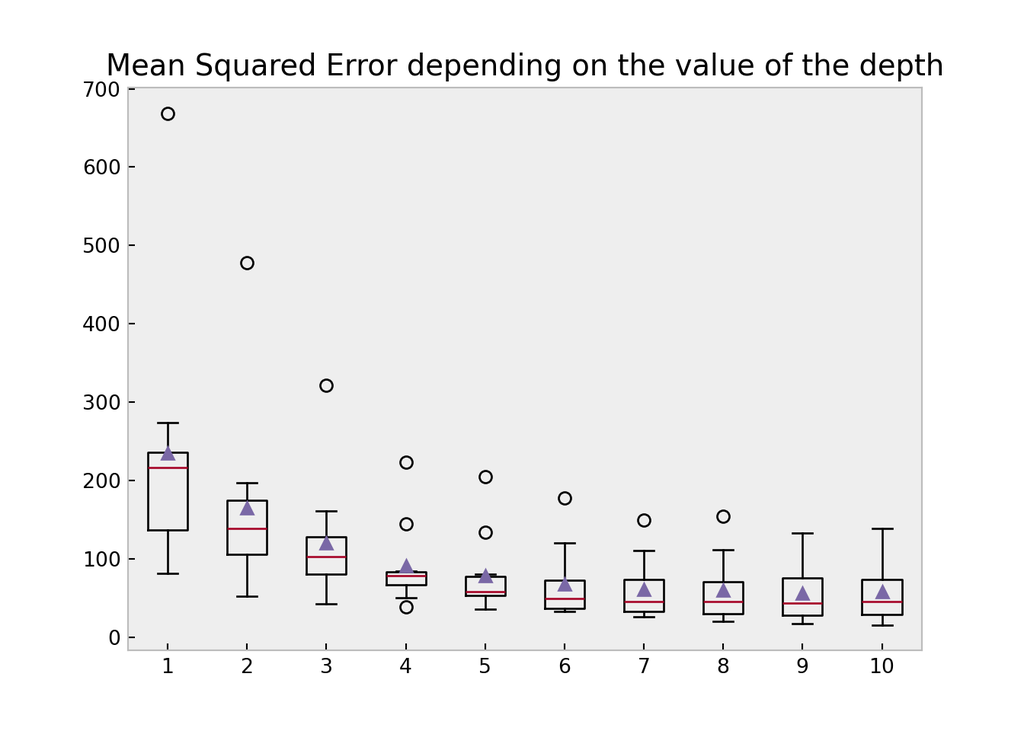

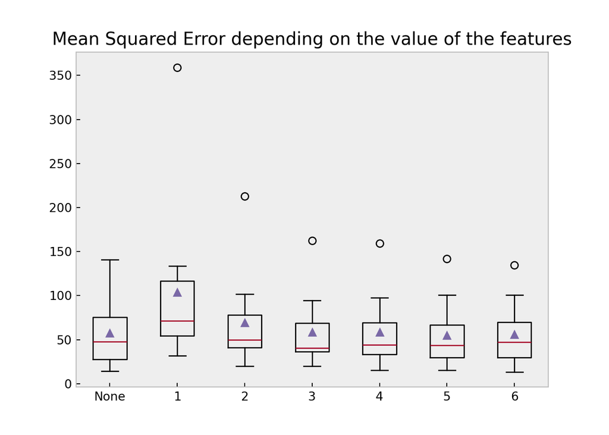

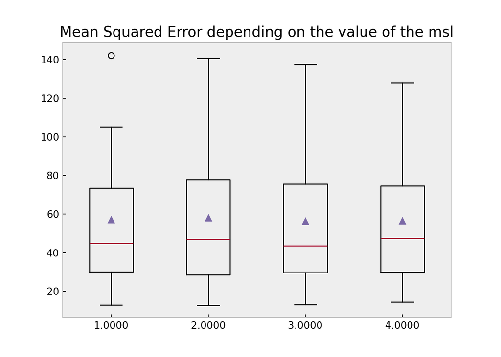

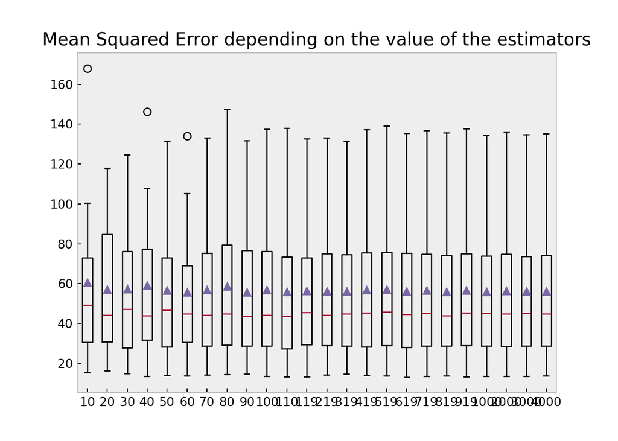

```python
def get_models_rf(choice):
    n_best = rf_params['n_estimators']
    ft_best = rf_params['max_features']
    depth_best = rf_params['max_depth']
    msl_best = rf_params['min_samples_leaf']
    models = dict()
    n_trees = list(range(10,n_best,10)) + list(range(n_best,1000,100)) + list(range(1000,5000,1000))
    if choice == 'estimators' :
        for n in n_trees:
            models[str(n)] = RandomForestRegressor(n_estimators=n, min_samples_leaf= msl_best ,max_depth = depth_best, max_features=ft_best )
    elif choice == 'msl' :
        for i in range(1,5):
            key = '%.4f' % i
            models[key] = RandomForestRegressor(min_samples_leaf= msl_best , n_estimators= n_best, max_depth = depth_best , max_features=ft_best  )
    elif choice == 'depth' :
        for i in range(1,11):
            models[str(i)] = RandomForestRegressor(max_depth=i,min_samples_leaf= msl_best ,n_estimators= n_best , max_features=ft_best )
    elif choice == 'features' :
        for i in [None, 1,2,3,4,5,6]:
            models[str(i)] = RandomForestRegressor(max_features=i ,max_depth=depth_best,min_samples_leaf= msl_best ,n_estimators= n_best)
    return models


def evaluate_model(model, X,y):
    cv = KFold(n_splits=10)
    mse_scorer = make_scorer(mean_squared_error, greater_is_better=False)
    scores = -cross_val_score(model, X, y, scoring= mse_scorer, cv=cv, n_jobs=-1)
    return scores


from sklearn.model_selection import train_test_split

for i in ['depth','features','msl','estimators']:
    models = get_models_rf(i)
    results, names = list(), list()
    for name, model in models.items():
        scores = evaluate_model(model, X,y)
        results.append(scores)
        names.append(name)
        #print('>%s %.3f' % (name, np.mean(scores)))
    plt.boxplot(results, labels=names, showmeans=True)
    plt.title(f'Mean Squared Error depending on the value of the {i}')
    plt.show()
```

### AdaBoost

AdaBoost, standing for adaptive boosting, is another ensemble learning method. The particularity of adaboost is the method by which the weak learners are constructed: each point in the dataset is assigned a weight, uniform at first. Then each time a weak learner is trained, the weights of the points are updated in order to give more weight to the points that are badly predicted by the model and less weight to those that are well predicted. The idea is that subsequent weak learners will be incentivized to learn patterns that have not been already learnt by the previous weak learners, hopefully improving the quality of the model as a whole.

#### Optimization of hyperparameters

In AdaBoost, the two most important hyperparameters are the number of weak learners to use and the learning rate, which translates as how much to reweight the points after each weak learner has been constructed. We will optimize over them by using a grid search approach, as it was the approach suggested for this document.

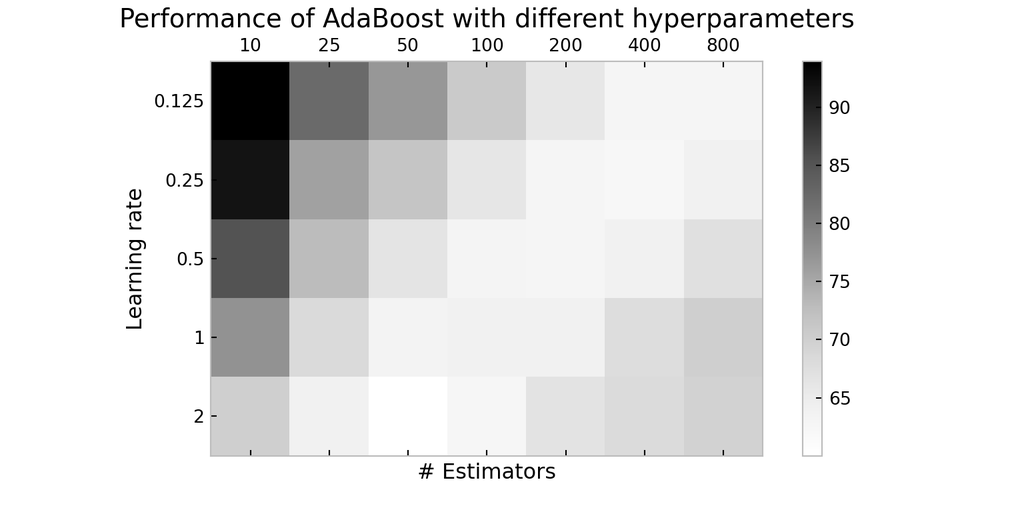

```python
from sklearn.ensemble import AdaBoostRegressor

grid = dict()
grid['n_estimators'] = [10, 25, 50, 100, 200, 400, 800]
grid['learning_rate'] = [2**i for i in range(-3, 2)]

mses_ada = np.zeros((len(grid["n_estimators"]), len(grid["learning_rate"])))

for i, n_estimators in enumerate(grid["n_estimators"]):
    for j, learning_rate in enumerate(grid["learning_rate"]):
        model_ada = AdaBoostRegressor(n_estimators=n_estimators,
                                      learning_rate=learning_rate)
        mses_ada[i,j] = sum(cross_val_score(
            model_ada, X0, y0, cv=kfold, n_jobs=-1, scoring='neg_mean_squared_error')) / n_splits

plt.rcParams["figure.figsize"] = (8, 4);
plt.rcParams['axes.grid'] = False
fig = plt.figure()
ax = fig.add_subplot(111)
cax = ax.matshow(-mses_ada.T, interpolation='nearest', cmap='Greys')
fig.colorbar(cax);

xaxis = np.arange(len(grid["n_estimators"]))
yaxis = np.arange(len(grid["learning_rate"]))
ax.set_xticks(xaxis)
ax.set_yticks(yaxis)
ax.set_xticklabels(grid["n_estimators"])
ax.set_yticklabels(grid["learning_rate"])
ax.set_ylabel("Learning rate")
ax.set_xlabel("# Estimators")
ax.set_title("Performance of AdaBoost with different hyperparameters");

plt.show()
```

```python
hyp_argmax = np.unravel_index(np.argmax(mses_ada), mses_ada.shape)
ada_params = {"n_estimators": grid['n_estimators'][hyp_argmax[0]],
              "learning_rate": grid['learning_rate'][hyp_argmax[1]]}

printstring = f"Best hyperparameters: \n\tn_estimators = {ada_params['n_estimators']}\n\
\tlearning_rate = {ada_params['learning_rate']}"
print(printstring + f"\nBest mean squared error: {-mses_ada[hyp_argmax]:.3f}")
```

```
Best hyperparameters:
    n_estimators = 50
    learning_rate = 2
Best mean squared error: 60.020
```

#### Impact of hyperparameters

Unfortunately, it seems that adaboost doesn’t perform very well on this problem, with a mean squared error almost twice as high as other models.

### Gradient boosting

Gradient boosting or GBM (gradient boosting models) is an extension of AdaBoost models. Its generalization comes from the fact that it allows optimization of an arbitrary differentiable loss function. At each step, the collective error given by the previously constructed weak learners is computed, and the next weak learner is constructed to minimize this residual.

#### Optimization of hyperparameters

For GBM we decided to optimize the number of weak learners in the model, the learning rate which again represents how much a new learner tries to correct the current residual, and since we are using decision trees as weak learners we also included their max depth. Once again, we will try to find the best set with a grid search.

```python
from sklearn.ensemble import GradientBoostingRegressor

grid = dict()
grid['n_estimators'] = [5*i for i in range(1,16)]
grid['learning_rate'] = [2**i for i in range(-7, 4)]
grid['max_depth'] = [3, 4, 5, 6, 7, 8]

model_GB = GradientBoostingRegressor()
tic = time.time()
grid_search = GridSearchCV(estimator=model_GB, param_grid=grid,
                           n_jobs=-1, cv=kfold, scoring='neg_mean_squared_error')
GB_params = grid_search.fit(X0, y0)
printstring = f"Grid search performed in {time.time() - tic:.0f}s\n"
printstring += str(GB_params.best_params_)
model_GB = GradientBoostingRegressor(**GB_params.best_params_)
CVmse = cross_val_score(model_GB, X0, y0, cv=kfold, scoring='neg_mean_squared_error')
print(printstring + f"\nAverage mean squared error for GBM: {-sum(CVmse)/n_splits:.2f}")
```

```
Grid search performed in 19s
{'learning_rate': 0.25, 'max_depth': 5, 'n_estimators': 60}
Average mean squared error for GBM: 23.10
```

#### Impact of hyperparameters

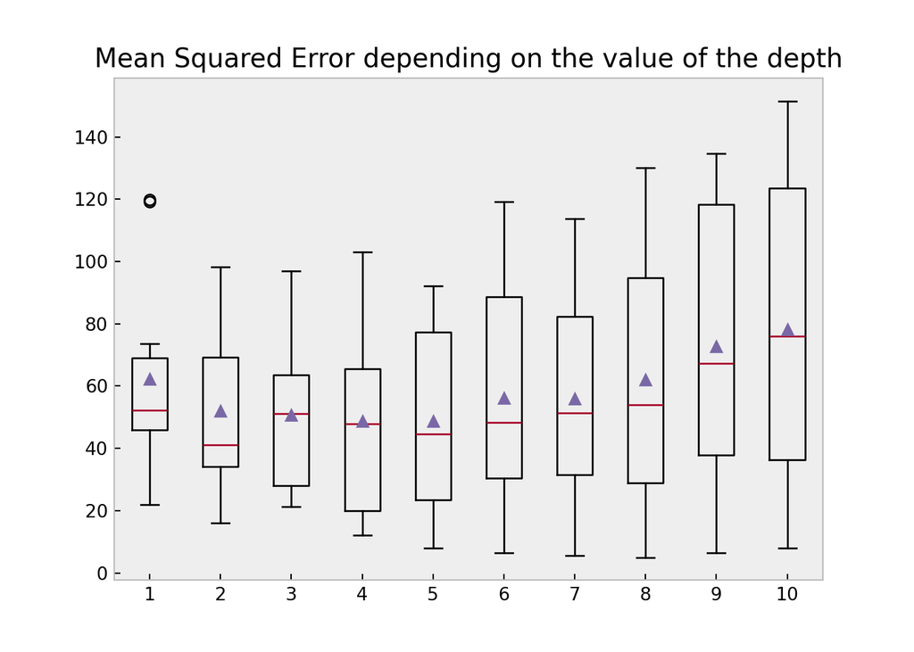

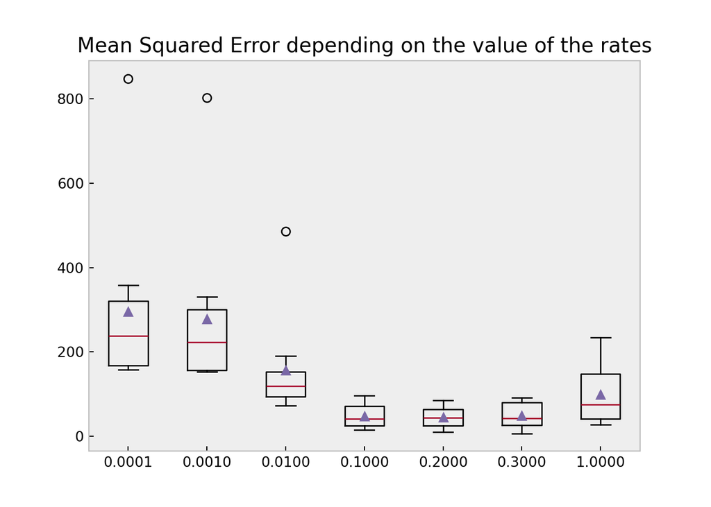

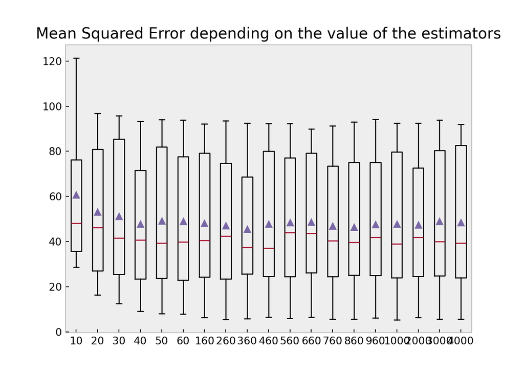

```python
def get_models_GB(choice):
    n_best = GB_params.best_params_['n_estimators']
    rate_best = GB_params.best_params_['learning_rate']
    depth_best = GB_params.best_params_['max_depth']
    models = dict()
    n_trees = list(range(10,n_best,10)) + list(range(n_best,1000,100)) + list(range(1000,5000,1000))
    if choice == 'estimators' :
        for n in n_trees:
            models[str(n)] = GradientBoostingRegressor(n_estimators=n, learning_rate = rate_best,max_depth = depth_best )
    elif choice == 'rates' :
        for i in [0.0001, 0.001, 0.01, 0.1, 0.2, 0.3,1.0]:
            key = '%.4f' % i
            models[key] = GradientBoostingRegressor(learning_rate=i, n_estimators= n_best, max_depth = depth_best )
    elif choice == 'depth' :
        for i in range(1,11):
            models[str(i)] = GradientBoostingRegressor(max_depth=i,learning_rate = rate_best,n_estimators= n_best)
    return models


for i in ['depth','rates','estimators']:
    models = get_models_GB(i)
    results, names = list(), list()
    for name, model in models.items():
        scores = evaluate_model(model, X, y)
        results.append(scores)
        names.append(name)
    plt.boxplot(results, labels=names, showmeans=True)
    plt.title(f'Mean Squared Error depending on the value of the {i}')
    plt.show()
```

As we did in the Random Forest part, to see the impact of every hyper parameter, we fix others and play with one.  
We can see that increase the value of the depth isn’t necessary since, after 5, MSE is increasing too.  
Also, we can conclude the same way with the learning rate, after 0.1, the model isn’t performing better. As when we used the Random Forest, we can see that at a time, performances are becoming more stable, and, even if we increase the number of estimator, MSE isn’t necessary lower.

## Comparison of models

We could select a good set of hyperparameters for each previous ensemble method. We will now compare them. For this, we will train the models with the best hyperparameters found on the whole training set, and compare their mean squared errors on the leftover *compare set*:

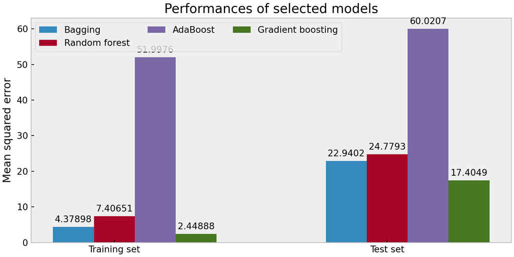

```python
plt.rcParams["figure.figsize"] = (8,4)

names = ["Training set", "Test set"]
model_mses = {"Bagging": [],
              "Random forest": [],
              "AdaBoost": [],
              "Gradient boosting": []
             }

# Evaluating the selected models
model_bagging = BaggingRegressor(bootstrap=True, bootstrap_features=False, **bag_params)
model_bagging = model_bagging.fit(X0, y0)
y0_pred = model_bagging.predict(X0)
y_pred = model_bagging.predict(X_compare)
model_mses["Bagging"].append(mean_squared_error(y0_pred, y0))
model_mses["Bagging"].append(mean_squared_error(y_pred, y_compare))

model_rf = RandomForestRegressor(**rf_params)
model_rf = model_rf.fit(X0, y0)
y0_pred = model_rf.predict(X0)
y_pred = model_rf.predict(X_compare)
model_mses["Random forest"].append(mean_squared_error(y0_pred, y0))
model_mses["Random forest"].append(mean_squared_error(y_pred, y_compare))

model_ada = AdaBoostRegressor(**ada_params)
model_ada = model_ada.fit(X0, y0)
y0_pred = model_ada.predict(X0)
y_pred = model_ada.predict(X_compare)
model_mses["AdaBoost"].append(mean_squared_error(y0_pred, y0))
model_mses["AdaBoost"].append(mean_squared_error(y_pred, y_compare))

model_GB = GradientBoostingRegressor(**GB_params.best_params_)
model_GB = model_GB.fit(X0, y0)
y0_pred = model_GB.predict(X0)
y_pred = model_GB.predict(X_compare)
model_mses["Gradient boosting"].append(mean_squared_error(y0_pred, y0))
model_mses["Gradient boosting"].append(mean_squared_error(y_pred, y_compare))

x = np.arange(len(names))
width = 0.15
multiplier = 0

fig, ax = plt.subplots(layout='constrained')
for attribute, measurement in model_mses.items():
    offset = width * multiplier
    rects = ax.bar(x + offset, measurement, width, label=attribute)
    ax.bar_label(rects, padding=3)
    multiplier += 1

ax.set_ylabel('Mean squared error')
ax.set_title('Performances of selected models')
ax.set_xticks(x + width, names)
ax.legend(loc='upper left', ncol=3)
plt.show()
```

The underperformance of AdaBoost, especially on the training set, appears perplexing. Either we may have overlooked a crucial parameter setting in its configuration, or the algorithm might not be well-suited for the given regression problem for some unexplained reason.